# lncRNA

**Libraries**

```r
library(rtracklayer)
library(GenomicFeatures)
library(txdbmaker)
library(Biostrings)
library(BSgenome)
library(BSgenomeForge)
library(dplyr)
library(GenomicRanges)
library(GenomeInfoDb)
library(Biostrings)
library(BSgenome)
library(ggplot2)
library(scales)
library(ggpointdensity)
```

**Loading data - Loading seqs + filtering**

```r
library(BSgenome.Dlaeve.NCBI.dlgm)
genome <- BSgenome.Dlaeve.NCBI.dlgm
```

```r
print(class(genome))
```

## [1] “BSgenome”

## attr(,“package”)

## [1] “BSgenome”

```r
length(genome)
```

## [1] 3497

```r
genome
```

## | BSgenome object

## | - organism: Deroceras laeve

## | - provider: NCBI

## | - genome: dl_gm

## | - 3497 sequence(s):

## | chr1 chr2 chr3 chr4

## | chr5 chr6 chr7 chr8

## | chr9 chr10 chr11 chr12

## | chr13 chr14 chr15 chr16

## | chr17 chr18 chr19 chr20

## | … … … …

## | HiC_scaffold_3481 HiC_scaffold_3482 HiC_scaffold_3483 HiC_scaffold_3484

## | HiC_scaffold_3485 HiC_scaffold_3486 HiC_scaffold_3487 HiC_scaffold_3488

## | HiC_scaffold_3489 HiC_scaffold_3490 HiC_scaffold_3491 HiC_scaffold_3492

## | HiC_scaffold_3493 HiC_scaffold_3494 HiC_scaffold_3495 HiC_scaffold_3496

## | HiC_scaffold_3497

## |

## | Tips: call ‘seqnames()’ on the object to get all the sequence names, call ‘seqinfo()’ to

## | get the full sequence info, use the ‘$’ or ‘[[’ operator to access a given sequence, see

## | ‘?BSgenome’ for more information.

```r
# names present in your BSgenome
nm  <- seqnames(genome)

# choose only proper chromosomes (e.g. chr1..chr31), ignore the HiC_scaffold zoo
keep <- intersect(paste0("chr", 1:31), nm)          # safe even if some are missing

# grab them quickly as a DNAStringSet (lightweight, fast)
genome_chr <- getSeq(genome, keep)

# sanity check
length(genome_chr); head(names(genome_chr))
```

## [1] 31## [1] “chr1” “chr2” “chr3” “chr4” “chr5” “chr6”

```r
transcriptome <- import("C:/Users/rafae/OneDrive/Desktop/Genomics/derLaeGenome_namesDlasi_v2.fasta.functional_note.pseudo_label.gff")
```

```r
transcriptome
```

## GRanges object with 1756563 ranges and 17 metadata columns:

## seqnames ranges strand | source type score

## |

## [1] HiC_scaffold_1005 6207-7268 - | EviAnn gene NA

## [2] HiC_scaffold_1005 6207-7268 - | EviAnn mRNA NA

## [3] HiC_scaffold_1005 6207-7268 - | EviAnn exon NA

## [4] HiC_scaffold_1005 6207-7268 - | EviAnn CDS NA

## [5] HiC_scaffold_1005 7529-9631 + | EviAnn gene NA

## … … … … . … … …

## [1756559] chr9 73153203-73153305 - | EviAnn CDS NA

## [1756560] chr9 73155022-73155165 - | EviAnn CDS NA

## [1756561] chr9 73157349-73157465 - | EviAnn CDS NA

## [1756562] chr9 73161856-73161986 - | EviAnn CDS NA

## [1756563] chr9 73179656-73179782 - | EviAnn CDS NA

## phase ID geneID gene_biotype

## [1] LOC_00034091 LOC_00034091 protein_coding

## [2] LOC_00034091-mRNA-1 LOC_00034091 protein_coding

## [3]

## [4] 0

## [5] LOC_00034092 LOC_00034092 protein_coding

## … … … … …

## [1756559] 0

## [1756560] 0

## [1756561] 0

… [43 líneas truncadas]

```r
table(transcriptome$gene_biotype)
```

## lncRNA processed_pseudogene protein_coding

## 1832 871 120268

```r
lncRNA <- transcriptome[transcriptome$type == "gene" & transcriptome$gene_biotype == "lncRNA"]
length(lncRNA)
```

## [1] 1832

```r
# keep only chromosomes present in genome_chr, drop scaffolds safely
lncRNA <- keepSeqlevels(lncRNA, seqlevels(genome_chr), pruning.mode = "coarse")

# now set seqinfo to match your chromosome-only genome
seqinfo(lncRNA) <- seqinfo(genome_chr)
```

```r
geneinfo <- mcols(lncRNA)[c("geneID","Note")]
geneinfo
```

## DataFrame with 1777 rows and 2 columns

## geneID Note

## 1 XLOC_013414U_lncRNA function unknown

## 2 XLOC_013424U_lncRNA function unknown

## 3 XLOC_012352U_lncRNA function unknown

## 4 XLOC_013428U_lncRNA function unknown

## 5 XLOC_012359U_lncRNA function unknown

## … … …

## 1773 XLOC_041835U_lncRNA function unknown

## 1774 XLOC_041852U_lncRNA function unknown

## 1775 XLOC_041854U_lncRNA function unknown

## 1776 XLOC_042465U_lncRNA function unknown

## 1777 XLOC_041888U_lncRNA function unknown

```r
lncRNA <- trim(lncRNA)
proteinGenes_seqs <- getSeq(genome_chr, lncRNA)
```

*Body*

```r
length(proteinGenes_seqs)
```

## [1] 1777

```r
proteinGenes_seqs
```

## DNAStringSet object of length 1777:

## width seq

## [1] 2900 AGGCCTTGATGGAGACAGCCTTAACCAGAATGTTCCT…GTTGAATAATGTATTTATTAAATGTTAAACAATGTC

## [2] 15361 AATTGTTTGCTCGTGGAATTCTTCTCTAGCTCCATGG…TACGGAAATAAATCTATGAATTAAAGAATGCATTGG

## [3] 822 AGATGTTGGCAGCCAAATTTCTCAAAGATCCAAGATG…TCTCTCACTTGAGGTACTGGCTTCAGCCCATTCTCT

## [4] 13564 AAAATAATCTAAGCCCTAAGCGATGGTTGCTTCTAGA…GAAGCCCTTGGTATTGGTATTTCATTTAATTGATTG

## [5] 1178 TACCGAGCAATTGTGTTTCCATGTATGGCTTATTTCG…GAACAGAATCTAATCTGCACATCTATTGCAAATTTC

## … … …

## [1773] 2284 CAGAATAATAATTTACTGAAGACAAAGTTCCATTAGA…TTTAAAATTGCTAACGACCCCCATATACTTCTGAAC

## [1774] 7823 ATTAGATCAGCAGACCACGCCGAGTCAACCAGACGTG…CTTCCAATACAGAGAACAGCATTTTACGTGAGTCCA

## [1775] 967 TGTATGCTTGAGCCTGCAGTGCGCTGTGATTGAGTTT…AGTTTGTGGAGGAGAGACACCGGCACAGATATGAGG

## [1776] 627 TCCCAGTTTTCACAAATGCTGTGCCATGTGATGCAAA…CAACCAATACTCGCTCCAGCACACTTAGCAAGGAAG

## [1777] 4136 GTTGTGATTTATAAATAAATAAAAGCAATCTGTGATG…AATTTGTCAAGCTATCGGCCAAAAACTTCATTTGTT

**Counting**

```r
letterFrequency_all <- letterFrequency(proteinGenes_seqs, c("A", "T", "C", "G")) %>% as.data.frame %>% tibble()
letterFrequency_all
```

| A | T | C | G |
| --- | --- | --- | --- |
| 640 | 796 | 971 | 493 |
| 4282 | 4056 | 3764 | 3259 |
| 185 | 262 | 227 | 148 |
| 3439 | 4447 | 2868 | 2810 |
| 365 | 432 | 187 | 194 |
| 386 | 373 | 453 | 240 |
| 1396 | 1194 | 891 | 811 |
| 6188 | 6600 | 4313 | 4197 |
| 312 | 219 | 211 | 158 |
| 752 | 886 | 391 | 591 |

[output cut: 1767 more lines]

```r
C_all <- letterFrequency_all[3]
G_all <- letterFrequency_all[4]
Width_all <- width(proteinGenes_seqs)
CG_all <- dinucleotideFrequency(proteinGenes_seqs)[,"CG"]
```

```r
OE_all = (CG_all*Width_all)/(C_all*G_all)
colnames(OE_all) <- c("OEindex")
OE_all
```

| OEindex |
| --- |
| 0.26655358 |
| 0.57227097 |
| 0.17127039 |
| 0.45947825 |
| 0.71437235 |
| 0.16026490 |
| 0.28510340 |
| 0.45415876 |
| 0.26996221 |
| 0.05669008 |

[output cut: 1767 more lines]

```r
cgContent_all = (C_all+G_all)/Width_all
colnames(cgContent_all) <- c("CGpercentage")
cgContent_all
```

| CGpercentage |
| --- |
| 0.5048276 |
| 0.4571968 |
| 0.4562044 |
| 0.4186081 |
| 0.3234295 |
| 0.4772727 |
| 0.3965517 |
| 0.3995680 |
| 0.4100000 |
| 0.3748092 |

[output cut: 1767 more lines]

```r
df <- cbind(OE_all,cgContent_all)
df
```

| OEindex | CGpercentage |
| --- | --- |
| 0.26655358 | 0.5048276 |
| 0.57227097 | 0.4571968 |
| 0.17127039 | 0.4562044 |
| 0.45947825 | 0.4186081 |
| 0.71437235 | 0.3234295 |
| 0.16026490 | 0.4772727 |
| 0.28510340 | 0.3965517 |
| 0.45415876 | 0.3995680 |
| 0.26996221 | 0.4100000 |
| 0.05669008 | 0.3748092 |

[output cut: 1767 more lines]

**Graphs**

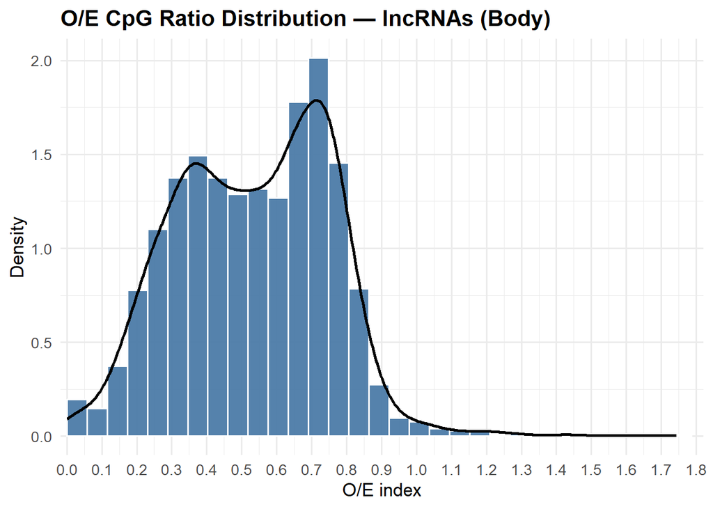

```r
x <- OE_all$OEindex
x <- x[is.finite(x)]
bw <- 2 * IQR(x) / length(x)^(1/3)
if (!is.finite(bw) || bw <= 0) bw <- diff(range(x)) / 80
xmin <- floor(min(x) * 10) / 10
xmax <- ceiling(max(x) * 10) / 10

ggplot(OE_all, aes(x = OEindex)) +
  geom_histogram(aes(y = after_stat(density)),
                 binwidth = bw, boundary = 0, closed = "left",
                 fill = "#4C7BA8", color = "white", alpha = 0.95) +
  geom_density(linewidth = 0.9, color = "black", alpha = 0.6) +
  scale_x_continuous(
    breaks = seq(xmin, xmax, by = 0.1),
    minor_breaks = seq(xmin, xmax, by = 0.05),
    labels = number_format(accuracy = 0.1),
    expand = expansion(mult = c(0.01, 0.02))
  ) +
  labs(
    title = "O/E CpG Ratio Distribution — lncRNAs (Body)",
    x = "O/E index",
    y = "Density"
  ) +
  theme_minimal(base_size = 13) +
  theme(
    panel.grid.minor = element_line(),
    plot.title = element_text(face = "bold")
  )
```

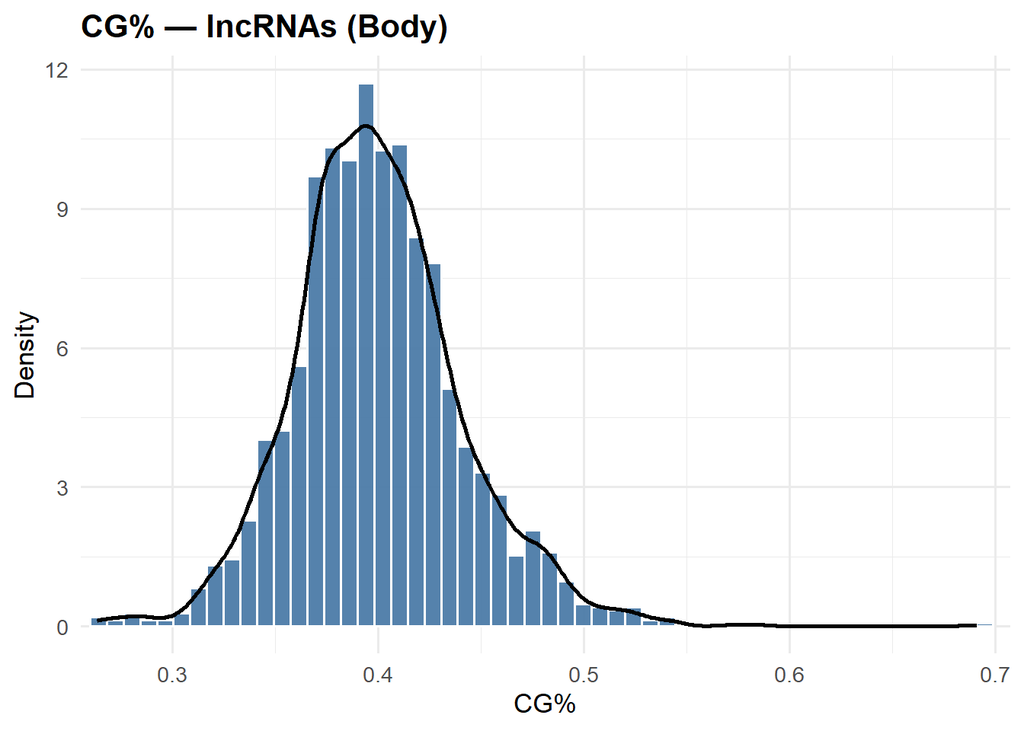

```r
x <- cgContent_all$CGpercentage
x <- x[is.finite(x)]
bw <- 2 * IQR(x) / length(x)^(1/3)
if (!is.finite(bw) || bw <= 0) bw <- diff(range(x)) / 80
xmin <- floor(min(x) * 10) / 10
xmax <- ceiling(max(x) * 10) / 10

ggplot(cgContent_all, aes(x = CGpercentage)) +
  geom_histogram(aes(y = after_stat(density)),
                 binwidth = bw, boundary = 0, closed = "left",
                 fill = "#4C7BA8", color = "white", alpha = 0.95) +
  geom_density(linewidth = 0.9, color = "black", alpha = 0.6) +
  scale_x_continuous(
    breaks = seq(xmin, xmax, by = 0.1),
    minor_breaks = seq(xmin, xmax, by = 0.05),
    labels = number_format(accuracy = 0.1),
    expand = expansion(mult = c(0.01, 0.02))
  ) +
  labs(
    title = "CG% — lncRNAs (Body)",
    x = "CG%",
    y = "Density"
  ) +
  theme_minimal(base_size = 13) +
  theme(
    panel.grid.minor = element_line(),
    plot.title = element_text(face = "bold")
  )
```

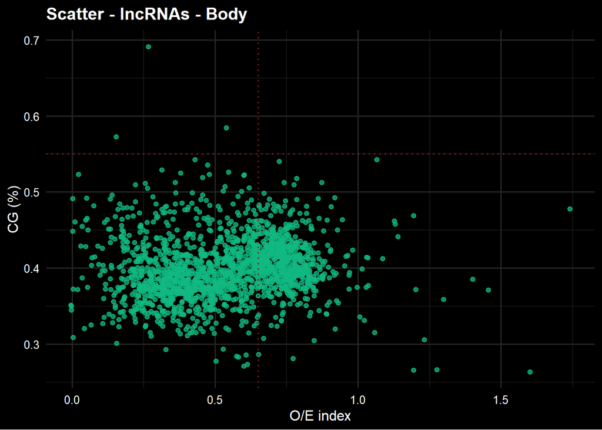

```r
plot_nice_dark <- function(d, x="OEindex", y="CGpercentage",
                           xthr=.65, ythr=.55, title="Scatter - lncRNAs - Body",
                           point_col="#10b981", thr_col="#7f1d1d"){   # green, violet
  dd <- data.frame(x=as.numeric(d[[x]]), y=as.numeric(d[[y]]))
  dd <- dd[is.finite(dd$x) & is.finite(dd$y), ]
  ggplot(dd, aes(x, y)) +
    geom_point(color=point_col, alpha=.75, size=1.6,
               position=position_jitter(width=.004, height=0)) +
    geom_vline(xintercept=xthr, color=thr_col, linewidth=.6, linetype="dotted") +
    geom_hline(yintercept=ythr, color=thr_col, linewidth=.6, linetype="dotted") +
    labs(title=title, x="O/E index", y="CG (%)") +
    theme_minimal(base_size=12) +
    theme(
      plot.background  = element_rect(fill="black", color=NA),
      panel.background = element_rect(fill="black", color=NA),
      panel.grid       = element_line(color="#242424"),
      axis.text        = element_text(color="white"),
      axis.title       = element_text(color="white"),
      plot.title       = element_text(color="white", face="bold")
    )
}

# use:
plot_nice_dark(df)
```

**PCA**

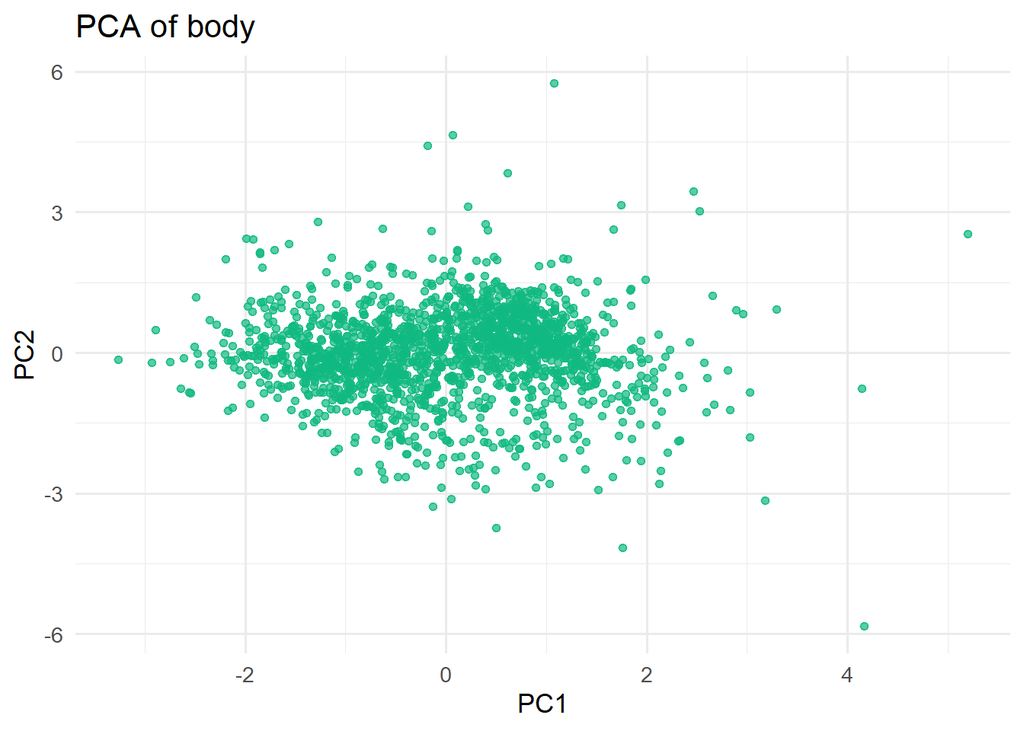

```r
# 1) Clean: keep numeric cols, drop NA/Inf rows, drop zero-variance cols
X <- df[, sapply(df, is.numeric), drop = FALSE]
X <- X[Reduce(`&`, lapply(X, is.finite)), , drop = FALSE]
X <- X[, sapply(X, function(z) sd(z) > 0), drop = FALSE]

# 2) PCA
pca <- prcomp(X, center = TRUE, scale. = TRUE)
pc  <- as.data.frame(pca$x[, 1:2, drop = FALSE])

ggplot(pc, aes(PC1, PC2)) +
  geom_point(alpha = .7, size = 1.6, color = "#10b981") +
  theme_minimal(base_size = 13) +
  labs(title = "PCA of body", x = "PC1", y = "PC2")
```

```r
summary(pca)
```

## Importance of components:

## PC1 PC2

## Standard deviation 1.0523 0.9449

## Proportion of Variance 0.5536 0.4464

## Cumulative Proportion 0.5536 1.0000

```r
cor(df$OEindex, df$CGpercentage)
```

## [1] NA

**K-Means**

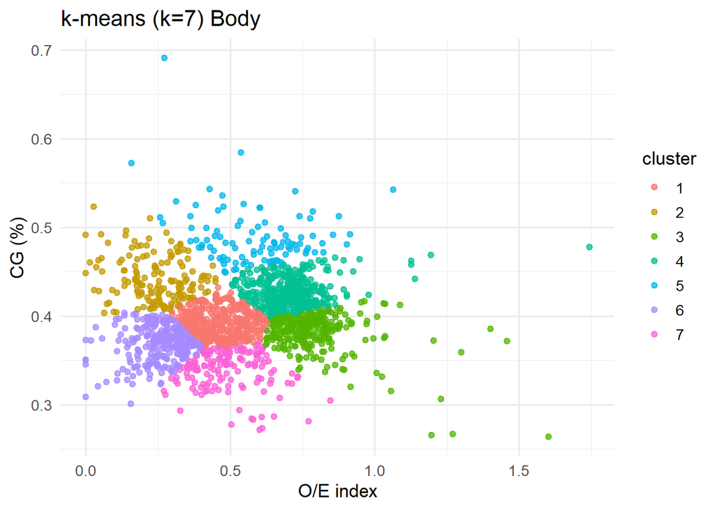

```r
# clean once; keep the mask so we can put labels back correctly
X <- df[, c("OEindex","CGpercentage")]
m <- is.finite(X$OEindex) & is.finite(X$CGpercentage)
Xc <- scale(X[m, , drop=FALSE])

set.seed(42)
k  <- 7
km <- kmeans(Xc, centers=k, nstart=50)

df$cluster <- NA_integer_
df$cluster[m] <- km$cluster
df$cluster <- factor(df$cluster)

ggplot(df[!is.na(df$cluster),], aes(OEindex, CGpercentage, color=cluster)) +
  geom_point(alpha=.75, size=1.7) +
  theme_minimal(base_size=13) +
  labs(title=sprintf("k-means (k=%d) Body", k),
       x="O/E index", y="CG (%)")
```

```r
#Add names
df <- cbind(geneinfo, df)
df
```

## DataFrame with 1777 rows and 5 columns

## geneID Note OEindex CGpercentage cluster

## 1 XLOC_013414U_lncRNA function unknown 0.266554 0.504828 5

## 2 XLOC_013424U_lncRNA function unknown 0.572271 0.457197 5

## 3 XLOC_012352U_lncRNA function unknown 0.171270 0.456204 2

## 4 XLOC_013428U_lncRNA function unknown 0.459478 0.418608 1

## 5 XLOC_012359U_lncRNA function unknown 0.714372 0.323430 7

## … … … … … …

## 1773 XLOC_041835U_lncRNA function unknown 0.387329 0.397548 1

## 1774 XLOC_041852U_lncRNA function unknown 0.312175 0.529337 5

## 1775 XLOC_041854U_lncRNA function unknown 0.180964 0.478800 2

## 1776 XLOC_042465U_lncRNA function unknown 0.282051 0.398724 6

## 1777 XLOC_041888U_lncRNA function unknown 0.234772 0.412718 2

```r
#Body list with cgi arquitecture
df_filtered_cgi_body <- dplyr::filter(as.data.frame(df), OEindex >= 0.65, CGpercentage >= .55)
df_filtered_cgi_body
```

| geneID | Note | OEindex | CGpercentage | cluster |
| --- | --- | --- | --- | --- |

```r
C_all_sum <- sum(C_all)
G_all_sum <- sum(G_all)
Width_all_sum <- sum(width(proteinGenes_seqs))
CG_all_sum <- sum(CG_all)
```

```r
C_all_sum <- as.numeric(C_all_sum)
G_all_sum  <- as.numeric(G_all_sum)
Width_all_sum <- as.numeric(Width_all_sum)
CG_all_sum <- as.numeric(CG_all_sum)
```

```r
#CG% sum - Body
cgContent_all_sum <- (C_all_sum+G_all_sum)/Width_all_sum
cgContent_all_sum
```

## [1] 0.4128035

```r
#OE Index sum - Body
OE_all_sum <- (CG_all_sum*Width_all_sum)/(C_all_sum*G_all_sum)
OE_all_sum
```

## [1] 0.5592485

```r
#Body sums totals
C_all_sum
```

## [1] 3994377

```r
G_all_sum
```

## [1] 4216017

```r
Width_all_sum
```

## [1] 19889352

```r
CG_all_sum
```

## [1] 473517

```r
cgContent_all_sum
```

## [1] 0.4128035

```r
OE_all_sum
```

## [1] 0.5592485

```r
#Porcentaje/Ratio de GCs en el cuerpo segun el span del cuerpo
CG_all_sum/Width_all_sum
```

## [1] 0.02380756

```r
#Porcentaje/Ratio de GC del cuerpo en comparacion al genoma
genomeCG_totalcount = 45535149
CG_all_sum/45535149
```

## [1] 0.01039893

*PROMOTORES*

```r
promotores_500bp <- promoters(lncRNA, upstream = 2000, downstream = 0)


seqlevelsStyle(promotores_500bp) <- seqlevelsStyle(genome)
promotores_500bp <- keepSeqlevels(
  promotores_500bp,
  intersect(seqlevels(promotores_500bp), seqlevels(genome)),
  pruning.mode = "coarse"
)
seqinfo(promotores_500bp) <- seqinfo(genome)[seqlevels(promotores_500bp)]
promotores_500bp <- trim(promotores_500bp)

promotores_500bp <- promotores_500bp[width(promotores_500bp) > 0]

starts <- start(promotores_500bp)
ends   <- end(promotores_500bp)
lens   <- seqlengths(promotores_500bp)[as.character(seqnames(promotores_500bp))]
start(promotores_500bp) <- pmax(1L, starts)
end(promotores_500bp)   <- pmin(ends, lens)


seqs_promotores_500bp <- getSeq(genome, promotores_500bp)


length(seqs_promotores_500bp)
```

## [1] 1777

```r
seqs_promotores_500bp
```

## DNAStringSet object of length 1777:

## width seq

## [1] 2000 TGGAGGAGTAGTGGGCCTGGGGTGGAGGAGTGGGGGC…TGTGGTGCCTGCCAACAAAGTCGTCCCTTCTGTCCAC

## [2] 2000 GAAATGGCAGGCCAAGGGATGGGAAGAGCCCTAGTGA…ACAACGGAAAAGTCTATGACCGGCTGGCTGCTACACA

## [3] 2000 CCTATCTTTAGCTTCATTTATCATTTCCGTAATTGAC…TATGCAACAGTTAATCATCAAGTAGTGTCTCATCGAC

## [4] 2000 CTAAAATAGTAGAAACGCCAAAGGGATGCCAACCCGG…TGTACGCATGCGAAAAAAGGCCGAGAACCGCTGTTCT

## [5] 2000 AAATGCAAATAAAATAATAACAAACAGTGCGATTCGT…GGATGTAATGGTAAGTACATAATTGAGGGGTGTATCG

## … … …

## [1773] 2000 TCATTATTCCATCAGTTAGGCCGATTAGTTTGATCAC…CAGCTGGTAGATACTGGACAACTCACAGAAACAATAG

## [1774] 2000 CCTTCTCCTAGGTGGATCGTCTTACTAGACTTTCGTG…GTTCCAGCAGACGCGCGAAAAGACGGGACTGTCAACC

## [1775] 2000 AGTTTGGTTTTGCAGCTGTGGACCAGGCTGACATGCC…AACGATAATAATACAATCTGACTTTCTGTTTATCAGG

## [1776] 2000 ATACTGTCTAATCCTTTACTACATAATCCTTTACTGC…TGTATAAACCTCACTGTATCCACTTGTTCTTTGTGAG

## [1777] 2000 AAATCGGAAGAAGTGTAGCAAGAGAAGAATAGTGAAC…TAGTAAAACACAAATTTAAACAAAACCAGAATGATGT

**Counting**

```r
letterFrequency_all_promoters <- letterFrequency(seqs_promotores_500bp, c("A", "T", "C", "G")) %>% as.data.frame %>% tibble()
letterFrequency_all_promoters
```

| A | T | C | G |
| --- | --- | --- | --- |
| 281 | 400 | 171 | 1148 |
| 630 | 528 | 375 | 467 |
| 448 | 549 | 635 | 368 |
| 627 | 546 | 384 | 443 |
| 459 | 839 | 331 | 371 |
| 524 | 575 | 458 | 443 |
| 578 | 581 | 426 | 415 |
| 510 | 726 | 388 | 376 |
| 639 | 568 | 370 | 423 |
| 576 | 674 | 307 | 443 |

[output cut: 1767 more lines]

```r
C_all_promoters <- letterFrequency_all_promoters[3]
G_all_promoters <- letterFrequency_all_promoters[4]
Width_all_promoters <- width(seqs_promotores_500bp)
CG_all_promoters <- dinucleotideFrequency(seqs_promotores_500bp)[,"CG"]
```

```r
C_all_promoters
```

| C |
| --- |
| 171 |
| 375 |
| 635 |
| 384 |
| 331 |
| 458 |
| 426 |
| 388 |
| 370 |
| 307 |

[output cut: 1767 more lines]

```r
G_all_promoters
```

| G |
| --- |
| 1148 |
| 467 |
| 368 |
| 443 |
| 371 |
| 443 |
| 415 |
| 376 |
| 423 |
| 443 |

[output cut: 1767 more lines]

```r
Width_all_promoters
```

## [1] 2000 2000 2000 2000 2000 2000 2000 2000 2000 2000 2000 2000 2000 2000 2000 2000

## [17] 2000 2000 2000 2000 2000 2000 2000 2000 2000 2000 2000 2000 2000 2000 2000 2000

## [33] 2000 2000 2000 2000 2000 2000 2000 2000 2000 2000 2000 2000 2000 2000 2000 2000

## [49] 2000 2000 2000 2000 2000 2000 2000 2000 2000 2000 2000 2000 2000 2000 2000 2000

## [65] 2000 2000 2000 2000 2000 2000 2000 2000 2000 2000 2000 2000 2000 2000 2000 2000

## [81] 2000 2000 2000 2000 2000 2000 2000 2000 2000 2000 2000 2000 2000 2000 2000 2000

## [97] 2000 2000 2000 2000 2000 2000 2000 2000 2000 2000 2000 2000 2000 2000 2000 2000

## [113] 2000 2000 2000 2000 2000 2000 2000 2000 2000 2000 2000 2000 2000 2000 2000 2000

## [129] 2000 2000 2000 2000 2000 2000 2000 2000 2000 2000 2000 2000 2000 2000 2000 2000

## [145] 2000 2000 2000 2000 2000 2000 2000 2000 2000 2000 2000 2000 2000 2000 2000 2000

## [161] 2000 2000 2000 2000 2000 2000 2000 2000 2000 2000 2000 2000 2000 2000 2000 2000

## [177] 2000 2000 2000 2000 2000 2000 2000 2000 2000 2000 2000 2000 2000 2000 2000 2000

## [193] 2000 2000 2000 2000 2000 2000 2000 2000 2000 2000 2000 2000 2000 2000 2000 2000

## [209] 2000 2000 2000 2000 2000 2000 2000 2000 2000 2000 2000 2000 2000 2000 2000 2000

## [225] 2000 2000 2000 2000 2000 2000 2000 2000 2000 2000 2000 2000 2000 2000 2000 2000

## [241] 2000 2000 2000 2000 2000 2000 2000 2000 2000 2000 2000 2000 2000 2000 2000 2000

## [257] 2000 2000 2000 2000 2000 2000 2000 2000 2000 2000 2000 2000 2000 2000 2000 2000

## [273] 2000 2000 2000 2000 2000 2000 2000 2000 2000 2000 2000 2000 2000 2000 2000 2000

## [289] 2000 2000 2000 2000 2000 2000 2000 2000 2000 2000 2000 2000 2000 2000 2000 2000

## [305] 2000 2000 2000 2000 2000 2000 2000 2000 2000 2000 2000 2000 2000 2000 2000 2000

## [321] 2000 2000 2000 2000 2000 2000 2000 2000 2000 2000 2000 2000 2000 2000 2000 2000

## [337] 2000 2000 2000 2000 2000 2000 2000 2000 2000 2000 2000 2000 2000 2000 2000 2000

## [353] 2000 2000 2000 2000 2000 2000 2000 2000 2000 2000 2000 2000 2000 2000 2000 2000

## [369] 2000 2000 2000 2000 2000 2000 2000 2000 2000 2000 2000 2000 2000 2000 2000 2000

## [385] 2000 2000 2000 2000 2000 2000 2000 2000 2000 2000 2000 2000 2000 2000 2000 2000

… [87 líneas truncadas]

```r
CG_all_promoters
```

## [1] 8 56 58 68 33 62 81 27 28 6 45 63 49 51 64 26 66 72 11 27 91

## [22] 66 63 45 52 62 65 52 52 55 49 50 75 85 58 62 90 24 49 62 29 34

## [43] 46 64 63 40 44 65 44 63 68 34 26 66 52 54 55 66 29 61 97 57 60

## [64] 70 74 27 19 16 71 64 61 53 70 41 51 30 54 55 27 23 84 45 57 52

## [85] 61 71 23 59 88 15 30 63 37 88 35 210 104 51 55 69 26 46 83 22 25

## [106] 23 74 15 20 49 73 92 74 43 63 79 64 105 59 45 48 66 73 38 28 22

## [127] 53 53 28 8 62 28 57 10 46 108 25 26 41 21 55 14 57 71 93 55 35

## [148] 24 74 73 65 35 70 8 91 84 75 56 50 48 51 21 81 50 9 70 40 55

## [169] 53 65 80 51 8 42 61 81 31 37 28 39 23 25 63 16 29 34 81 84 39

## [190] 43 35 68 44 53 25 32 68 63 41 67 60 94 12 50 41 68 35 36 70 38

## [211] 49 74 28 32 17 58 71 30 60 24 53 35 51 47 61 81 82 44 50 86 22

## [232] 34 60 60 66 44 31 21 108 44 84 11 60 72 8 53 6 78 63 85 16 24

## [253] 24 71 28 41 54 40 59 66 70 30 25 27 53 53 61 60 29 96 31 18 39

## [274] 77 54 25 94 27 70 54 69 19 41 68 69 26 2 58 69 69 17 75 30 54

## [295] 61 57 15 105 23 66 110 32 100 73 27 59 78 65 57 60 51 51 84 124 30

## [316] 52 87 54 46 59 65 77 61 19 56 92 23 25 62 67 22 21 12 26 68 36

## [337] 18 43 49 103 57 50 44 63 45 20 107 103 45 25 71 62 67 65 40 76 10

## [358] 50 46 53 83 50 61 72 28 68 40 77 60 39 52 42 47 86 15 55 50 25

## [379] 51 41 61 51 21 52 54 54 66 42 56 75 49 78 82 82 47 72 36 18 18

## [400] 75 43 33 56 85 62 23 0 74 48 60 34 18 31 20 58 51 79 15 14 48

## [421] 58 86 43 49 48 44 80 71 43 58 2 64 24 22 76 56 19 37 28 28 56

## [442] 58 68 54 16 66 54 13 41 42 33 34 53 63 40 10 48 74 48 4 28 22

## [463] 59 97 77 71 46 37 64 62 64 61 30 25 92 70 57 18 30 60 36 65 9

## [484] 97 25 62 83 83 41 90 43 85 45 54 46 51 30 29 67 45 46 46 31 8

## [505] 49 75 12 93 58 50 93 44 101 52 29 56 70 47 45 44 52 42 57 51 103

… [60 líneas truncadas]

```r
OE_all_promoters = (CG_all_promoters*Width_all_promoters)/(C_all_promoters*G_all_promoters)
colnames(OE_all_promoters) <- c("OEindex")
OE_all_promoters
```

| OEindex |
| --- |
| 0.08150457 |
| 0.63954318 |
| 0.49640534 |
| 0.79947329 |
| 0.53745491 |
| 0.61115656 |
| 0.91634142 |
| 0.37014696 |
| 0.35780461 |
| 0.08823465 |

[output cut: 1767 more lines]

```r
cgContent_all_promoters = (C_all_promoters+G_all_promoters)/Width_all_promoters
colnames(cgContent_all_promoters) <- c("CGpercentage")
cgContent_all_promoters
```

| CGpercentage |
| --- |
| 0.6595 |
| 0.4210 |
| 0.5015 |
| 0.4135 |
| 0.3510 |
| 0.4505 |
| 0.4205 |
| 0.3820 |
| 0.3965 |
| 0.3750 |

[output cut: 1767 more lines]

```r
df_promoters <- cbind(OE_all_promoters,cgContent_all_promoters)
df_promoters
```

| OEindex | CGpercentage |
| --- | --- |
| 0.08150457 | 0.6595 |
| 0.63954318 | 0.4210 |
| 0.49640534 | 0.5015 |
| 0.79947329 | 0.4135 |
| 0.53745491 | 0.3510 |
| 0.61115656 | 0.4505 |
| 0.91634142 | 0.4205 |
| 0.37014696 | 0.3820 |
| 0.35780461 | 0.3965 |
| 0.08823465 | 0.3750 |

[output cut: 1767 more lines]

**Graphs**

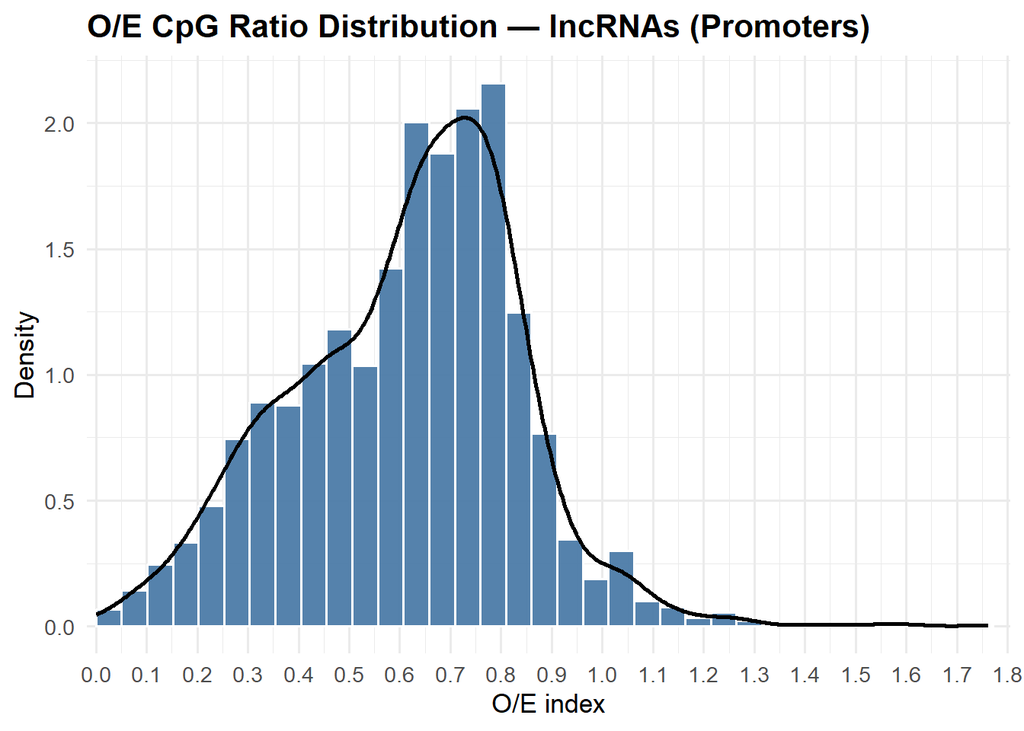

```r
x <- OE_all_promoters$OEindex
x <- x[is.finite(x)]
bw <- 2 * IQR(x) / length(x)^(1/3)
if (!is.finite(bw) || bw <= 0) bw <- diff(range(x)) / 80
xmin <- floor(min(x) * 10) / 10
xmax <- ceiling(max(x) * 10) / 10

ggplot(OE_all_promoters, aes(x = OEindex)) +
  geom_histogram(aes(y = after_stat(density)),
                 binwidth = bw, boundary = 0, closed = "left",
                 fill = "#4C7BA8", color = "white", alpha = 0.95) +
  geom_density(linewidth = 0.9, color = "black", alpha = 0.6) +
  scale_x_continuous(
    breaks = seq(xmin, xmax, by = 0.1),
    minor_breaks = seq(xmin, xmax, by = 0.05),
    labels = number_format(accuracy = 0.1),
    expand = expansion(mult = c(0.01, 0.02))
  ) +
  labs(
    title = "O/E CpG Ratio Distribution — lncRNAs (Promoters)",
    x = "O/E index",
    y = "Density"
  ) +
  theme_minimal(base_size = 13) +
  theme(
    panel.grid.minor = element_line(),
    plot.title = element_text(face = "bold")
  )
```

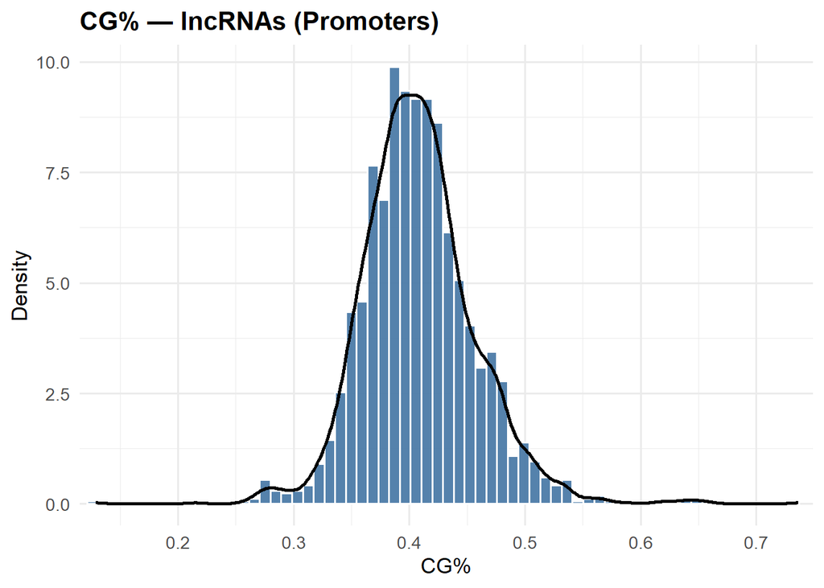

```r
x <- cgContent_all_promoters$CGpercentage
x <- x[is.finite(x)]
bw <- 2 * IQR(x) / length(x)^(1/3)
if (!is.finite(bw) || bw <= 0) bw <- diff(range(x)) / 80
xmin <- floor(min(x) * 10) / 10
xmax <- ceiling(max(x) * 10) / 10

ggplot(cgContent_all_promoters, aes(x = CGpercentage)) +
  geom_histogram(aes(y = after_stat(density)),
                 binwidth = bw, boundary = 0, closed = "left",
                 fill = "#4C7BA8", color = "white", alpha = 0.95) +
  geom_density(linewidth = 0.9, color = "black", alpha = 0.6) +
  scale_x_continuous(
    breaks = seq(xmin, xmax, by = 0.1),
    minor_breaks = seq(xmin, xmax, by = 0.05),
    labels = number_format(accuracy = 0.1),
    expand = expansion(mult = c(0.01, 0.02))
  ) +
  labs(
    title = "CG% — lncRNAs (Promoters)",
    x = "CG%",
    y = "Density"
  ) +
  theme_minimal(base_size = 13) +
  theme(
    panel.grid.minor = element_line(),
    plot.title = element_text(face = "bold")
  )
```

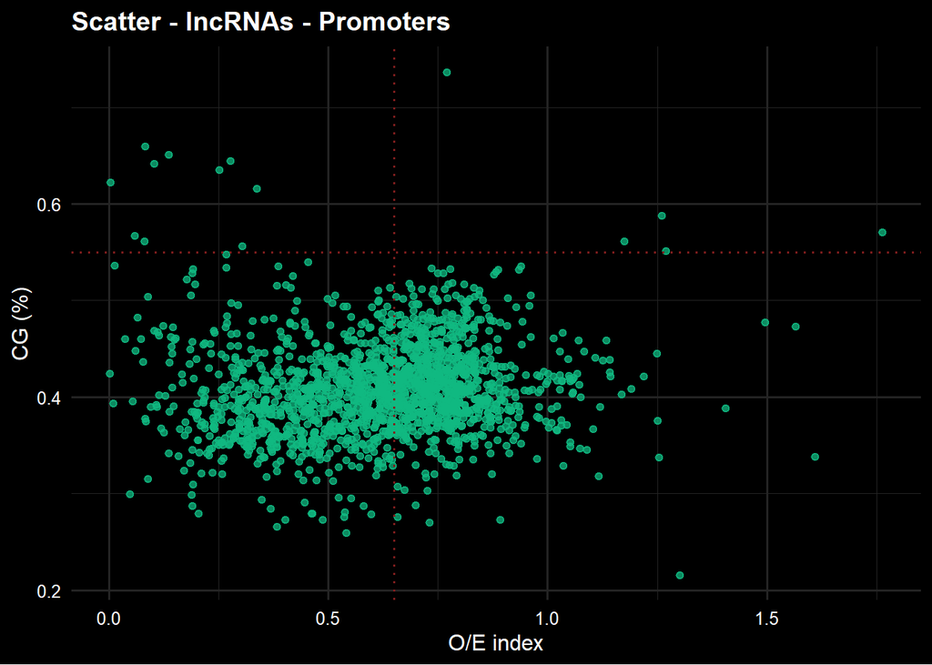

```r
plot_nice_dark <- function(d, x="OEindex", y="CGpercentage",
                           xthr=.65, ythr=.55, title="Scatter - lncRNAs - Promoters",
                           point_col="#10b981", thr_col="#7f1d1d"){   # green, violet
  dd <- data.frame(x=as.numeric(d[[x]]), y=as.numeric(d[[y]]))
  dd <- dd[is.finite(dd$x) & is.finite(dd$y), ]
  ggplot(dd, aes(x, y)) +
    geom_point(color=point_col, alpha=.75, size=1.6,
               position=position_jitter(width=.004, height=0)) +
    geom_vline(xintercept=xthr, color=thr_col, linewidth=.6, linetype="dotted") +
    geom_hline(yintercept=ythr, color=thr_col, linewidth=.6, linetype="dotted") +
    labs(title=title, x="O/E index", y="CG (%)") +
    theme_minimal(base_size=12) +
    theme(
      plot.background  = element_rect(fill="black", color=NA),
      panel.background = element_rect(fill="black", color=NA),
      panel.grid       = element_line(color="#242424"),
      axis.text        = element_text(color="white"),
      axis.title       = element_text(color="white"),
      plot.title       = element_text(color="white", face="bold")
    )
}

# use:
plot_nice_dark(df_promoters)
```

**PCA**

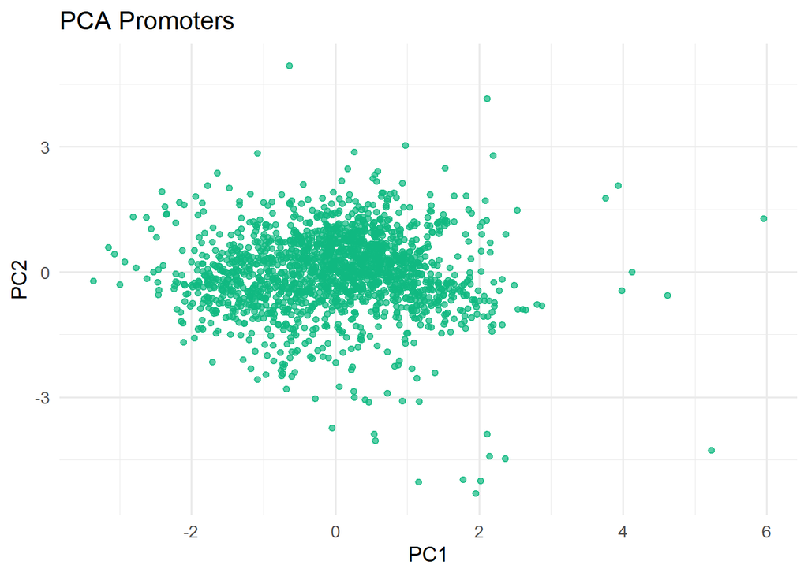

```r
# 1) Clean: keep numeric cols, drop NA/Inf rows, drop zero-variance cols
X <- df_promoters[, sapply(df_promoters, is.numeric), drop = FALSE]
X <- X[Reduce(`&`, lapply(X, is.finite)), , drop = FALSE]
X <- X[, sapply(X, function(z) sd(z) > 0), drop = FALSE]

# 2) PCA
pca <- prcomp(X, center = TRUE, scale. = TRUE)
pc  <- as.data.frame(pca$x[, 1:2, drop = FALSE])

ggplot(pc, aes(PC1, PC2)) +
  geom_point(alpha = .7, size = 1.6, color = "#10b981") +
  theme_minimal(base_size = 13) +
  labs(title = "PCA Promoters", x = "PC1", y = "PC2")
```

```r
summary(pca)
```

## Importance of components:

## PC1 PC2

## Standard deviation 1.0535 0.9435

## Proportion of Variance 0.5549 0.4451

## Cumulative Proportion 0.5549 1.0000

```r
cor(df$OEindex, df$CGpercentage)
```

## [1] NA

**K-Means**

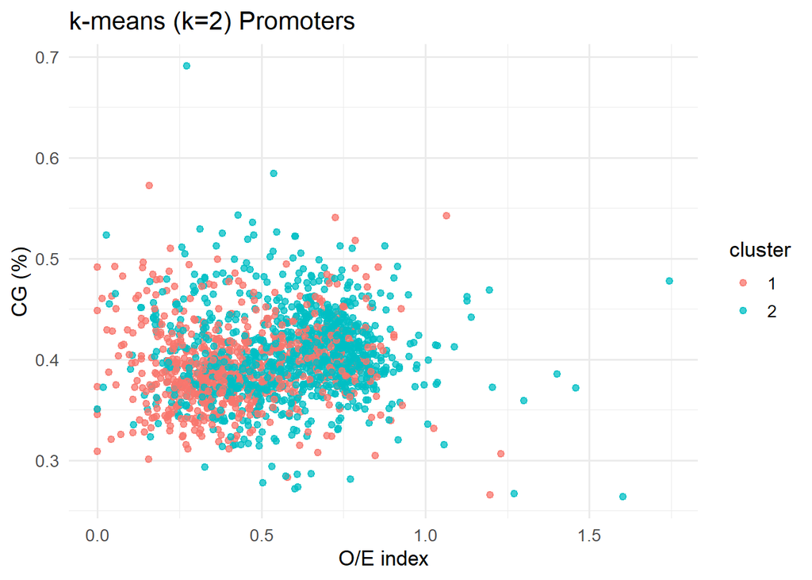

```r
# clean once; keep the mask so we can put labels back correctly
X <- df_promoters[, c("OEindex","CGpercentage")]
m <- is.finite(X$OEindex) & is.finite(X$CGpercentage)
Xc <- scale(X[m, , drop=FALSE])

set.seed(42)
k  <- 2
km <- kmeans(Xc, centers=k, nstart=50)

df$cluster <- NA_integer_
df$cluster[m] <- km$cluster
df$cluster <- factor(df$cluster)

ggplot(df[!is.na(df$cluster),], aes(OEindex, CGpercentage, color=cluster)) +
  geom_point(alpha=.75, size=1.7) +
  theme_minimal(base_size=13) +
  labs(title=sprintf("k-means (k=%d) Promoters", k),
       x="O/E index", y="CG (%)")
```

```r
#Add names
df_promoters <- cbind(geneinfo, df_promoters)
df_promoters
```

## DataFrame with 1777 rows and 4 columns

## geneID Note OEindex CGpercentage

## 1 XLOC_013414U_lncRNA function unknown 0.0815046 0.6595

## 2 XLOC_013424U_lncRNA function unknown 0.6395432 0.4210

## 3 XLOC_012352U_lncRNA function unknown 0.4964053 0.5015

## 4 XLOC_013428U_lncRNA function unknown 0.7994733 0.4135

## 5 XLOC_012359U_lncRNA function unknown 0.5374549 0.3510

## … … … … …

## 1773 XLOC_041835U_lncRNA function unknown 0.414015 0.4770

## 1774 XLOC_041852U_lncRNA function unknown 0.833734 0.4335

## 1775 XLOC_041854U_lncRNA function unknown 0.369657 0.3605

## 1776 XLOC_042465U_lncRNA function unknown 0.533682 0.2760

## 1777 XLOC_041888U_lncRNA function unknown 0.417871 0.3860

```r
#Promoters list with cgi arquitecture
df_filtered_cgi_promoters <- dplyr::filter(as.data.frame(df_promoters), OEindex >= 0.65, CGpercentage >= .55)
df_filtered_cgi_promoters
```

| geneID | Note | OEindex | CGpercentage |
| --- | --- | --- | --- |
| XLOC_014451U_lncRNA |  | 1.2573871 | 0.5875 |
| XLOC_016844U_lncRNA |  | 1.7621145 | 0.5705 |
| XLOC_027046U_lncRNA |  | 1.2705531 | 0.5510 |
| XLOC_028569U_lncRNA |  | 1.1748604 | 0.5615 |
| XLOC_035727U_lncRNA |  | 0.7675684 | 0.7365 |

**Promoters Sum Count**

```r
C_all_sum_promoters <- sum(C_all_promoters)
G_all_sum_promoters <- sum(G_all_promoters)
Width_all_sum_promoters <- sum(width(seqs_promotores_500bp))
CG_all_sum_promoters <- sum(CG_all_promoters)
```

```r
C_all_sum_promoters <- as.numeric(C_all_sum_promoters)
G_all_sum_promoters  <- as.numeric(G_all_sum_promoters)
Width_all_sum_promoters <- as.numeric(Width_all_sum_promoters)
CG_all_sum_promoters <- as.numeric(CG_all_sum_promoters)
```

```r
C_all_sum_promoters
```

## [1] 727908

```r
G_all_sum_promoters
```

## [1] 723546

```r
Width_all_sum_promoters
```

## [1] 3554000

```r
CG_all_sum_promoters
```

## [1] 90282

```r
#CG% sum - Body
cgContent_all_sum_promoters <- (C_all_sum_promoters+G_all_sum_promoters)/Width_all_sum_promoters
cgContent_all_sum_promoters
```

## [1] 0.4084001

```r
#OE Index sum - Body
OE_all_sum_promoters <- (CG_all_sum_promoters*Width_all_sum_promoters)/(C_all_sum_promoters*G_all_sum_promoters)
OE_all_sum_promoters
```

## [1] 0.6092225

```r
#Body sums totals
C_all_sum_promoters
```

## [1] 727908

```r
G_all_sum_promoters
```

## [1] 723546

```r
Width_all_sum_promoters
```

## [1] 3554000

```r
CG_all_sum_promoters
```

## [1] 90282

```r
cgContent_all_sum_promoters
```

## [1] 0.4084001

```r
OE_all_sum_promoters
```

## [1] 0.6092225

```r
#Porcentaje/Ratio de GCs en el cuerpo segun el span del promoters
CG_all_sum_promoters/Width_all_sum_promoters
```

## [1] 0.02540293

```r
#Porcentaje/Ratio de GC del cuerpo en comparacion al genoma
genomeCG_totalcount = 45535149
CG_all_sum_promoters/45535149
```

## [1] 0.001982688